# Analyzing Russian Trolls: Tidyverse & Text

Ryan Wesslen

2/26/2018

## Russian Trolls

Last week, [NBC released a dataset of over 200,000 Russian troll tweets](https://www.nbcnews.com/tech/social-media/now-available-more-200-000-deleted-russian-troll-tweets-n844731); for more information, see [Economist](https://www.economist.com/news/leaders/21737276-and-why-wests-response-inadequate-how-putin-meddles-western-democracies) and New York Times Daily Podcast).

[figure not shown]

Source: The Economist

I’ll use the `tidyverse` (via `readr`) package to import the flat files (csv’s).

```r
library(tidyverse)

url <- "http://nodeassets.nbcnews.com/russian-twitter-trolls/tweets.csv"
tweets <- read_csv(url)

user.url <- "http://nodeassets.nbcnews.com/russian-twitter-trolls/users.csv"
users <- read_csv(user.url)
```

### Who are they?

```r
tweets %>%
  count(user_key, sort = TRUE) %>%
  mutate(percent = n / sum(n)) %>%
  head(n = 10)
```

```
## # A tibble: 10 x 3
##    user_key           n percent
##    <chr>          <int>   <dbl>
##  1 ameliebaldwin   9269  0.0456
##  2 hyddrox         6813  0.0335
##  3 giselleevns     6652  0.0327
##  4 patriotblake    4140  0.0203
##  5 thefoundingson  3663  0.0180
##  6 melvinsroberts  3346  0.0164
##  7 mrclydepratt    3263  0.0160
##  8 brianaregland   3261  0.0160
##  9 leroylovesusa   3229  0.0159
## 10 baobaeham       3215  0.0158
```

```r
users %>%
  arrange(desc(followers_count)) %>%
  select(screen_name, name, location, followers_count) %>%
  head(n = 10)
```

```
## # A tibble: 10 x 4
##    screen_name    name                location         followers_count
##    <chr>          <chr>               <chr>                      <int>
##  1 MaxDementiev   Максим Дементьев    <NA>                       98412
##  2 KadirovRussia  Рамзан Кадыров      <NA>                       94773
##  3 Jenn_Abrams    Jenna Abrams        USA                        61609
##  4 TodayNYCity    New York City Today New York, NY               60897
##  5 LavrovMuesli   Мюсли Лаврова       <NA>                       47080
##  6 coldwar20_ru   Холодная Война 2.0  Россия, Москва             44470
##  7 Politweecs     Politweecs          United States              32846
##  8 WashingtOnline Washington Online   Washington, D.C.           31729
##  9 PigeonToday    Pigeon Today        United States              29524
## 10 NewOrleansON   New Orleans Online  New Orleans, LA            27745
```

Some clearly had ties to Russia, while others posed as media outlets or individuals.

Let’s examine Jenn_Abrams (see [the Guardian article](https://www.theguardian.com/technology/shortcuts/2017/nov/03/jenna-abrams-the-trump-loving-twitter-star-who-never-really-existed)).

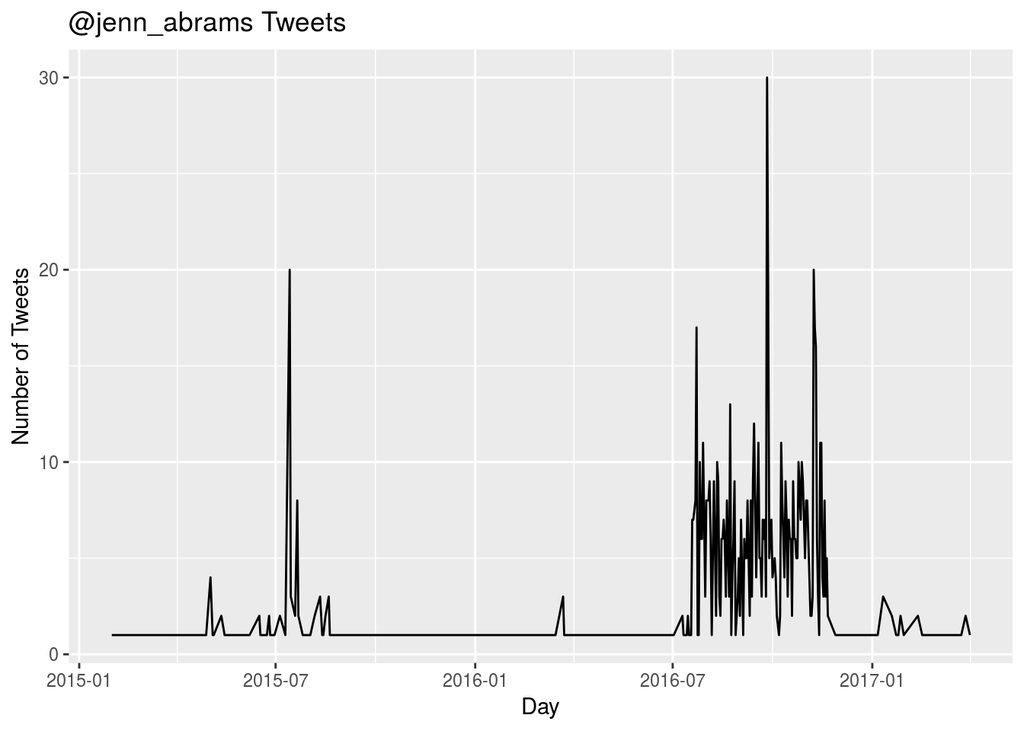

```r
tweets %>%
  filter(user_key == "jenn_abrams") %>%
  group_by(Date = as.Date(created_str)) %>%
  summarise(Count=n()) %>%
  ggplot(aes(x = Date, y = Count)) +
  geom_line() +
  labs(title = "@jenn_abrams Tweets",
       x = "Day",
       y = "Number of Tweets")
```

### What were the top tweets by retweet and favorite (likes) counts?

```r
tweets %>%
  arrange(desc(retweet_count)) %>%
  select(user_key, created_str, text, retweet_count) %>%
  head(n=10)
```

```
## # A tibble: 10 x 4
##    user_key        created_str         text                  retweet_count
##    <chr>           <dttm>              <chr>                         <int>
##  1 trayneshacole   2016-11-17 20:27:21 go all the way off h…         20494
##  2 gloed_up        2016-03-12 19:50:32 "#AnthonyCage was bl…         18209
##  3 crystal1johnson 2016-10-10 22:55:10 "When It’s slowly be…         13636
##  4 ten_gop         2016-10-11 02:11:02 "OMG, this new Anti-…         12078
##  5 ten_gop         2016-10-18 18:44:14 "RT the hell out of …         12042
##  6 crystal1johnson 2016-06-04 01:06:58 Muhammad Ali, the on…         11616
##  7 jenn_abrams     2016-09-18 16:42:48 "Some guy right in H…         11363
##  8 crystal1johnson 2016-10-09 01:27:00 3 Black children car…         10823
##  9 ten_gop         2016-10-20 05:40:07 "BREAKING🚨 \n\nHilla…         10467
## 10 bleepthepolice  2016-09-21 15:37:27 "Wow. Hadn't thought…         10310
```

```r
tweets %>%
  arrange(desc(favorite_count)) %>%
  select(user_key, created_str, text, favorite_count) %>%
  head(n=10)
```

```
## # A tibble: 10 x 4
##    user_key        created_str         text                 favorite_count
##    <chr>           <dttm>              <chr>                         <int>
##  1 trayneshacole   2016-11-17 20:27:21 go all the way off …          26655
##  2 jenn_abrams     2016-09-18 16:42:48 "Some guy right in …          16068
##  3 crystal1johnson 2016-10-10 22:55:10 "When It’s slowly b…          12815
##  4 ten_gop         2016-10-11 02:11:02 "OMG, this new Anti…          10867
##  5 ten_gop         2016-10-20 05:40:07 "BREAKING🚨 \n\nHill…          10437
##  6 crystal1johnson 2016-10-09 01:27:00 3 Black children ca…          10340
##  7 trayneshacole   2016-11-10 22:50:19 "White boyfriend sh…           9265
##  8 pamela_moore13  2016-06-16 23:35:47 "I would rather tak…           9242
##  9 crystal1johnson 2016-06-04 01:06:58 Muhammad Ali, the o…           8969
## 10 bleepthepolice  2016-09-21 15:37:27 "Wow. Hadn't though…           8495
```

New highly infamous trolls pop up like [@crystal1johnson](https://tweetsave.com/crystal1johnson) (who even [Twitter CEO Jack Dorsey retweeted](https://arstechnica.com/gaming/2017/10/report-twitter-ceo-took-a-russian-impostors-bait-in-2016/)) or @ten_gop, see [Vox](https://www.vox.com/policy-and-politics/2017/10/19/16504510/ten-gop-twitter-russia) or [CNN](https://www.cnn.com/2018/02/16/politics/who-is-ten-gop/index.html).

### Plotting tweets over time

A good start is to plot the number of tweets by date. We’ll use `ggplot2`

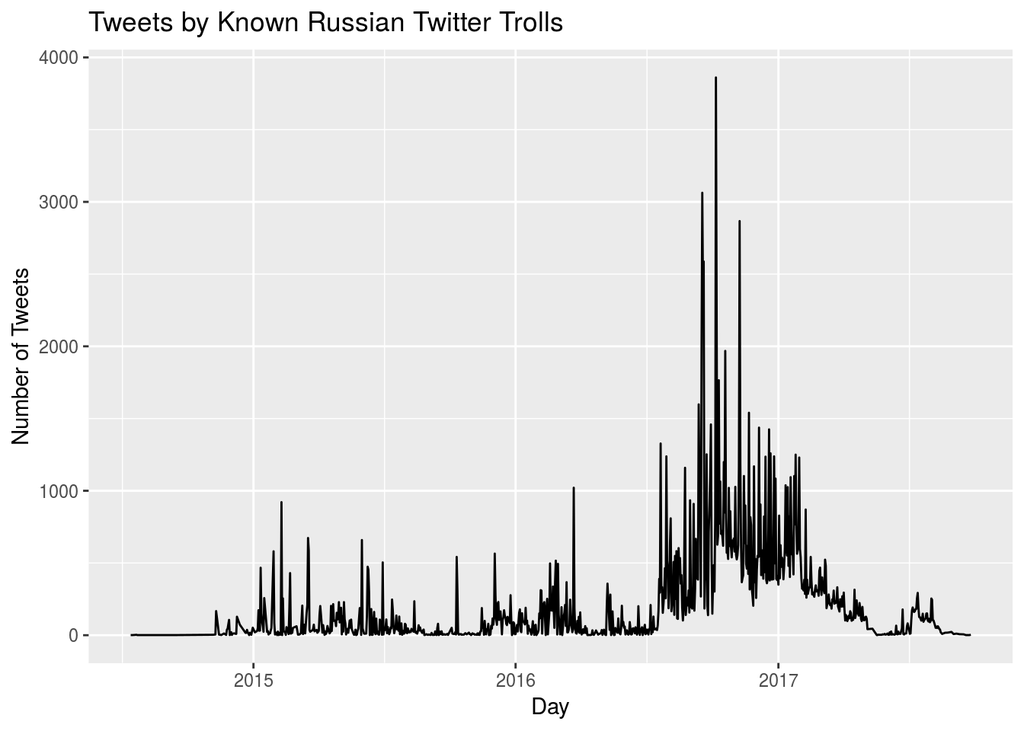

```r
tweets %>%
  count(Date = as.Date(created_str)) %>%
  ggplot(aes(x = Date, y = n)) +
  geom_line() +
  labs(title = "Tweets by Known Russian Twitter Trolls",
       x = "Day",
       y = "Number of Tweets")
```

What’s clear is that their activity started back in 2014 but really started to pick up around mid 2016, averaging hundreds to thousands of tweets per day.

Let’s see the trends by counting the number of tweets that contain politically related terms.

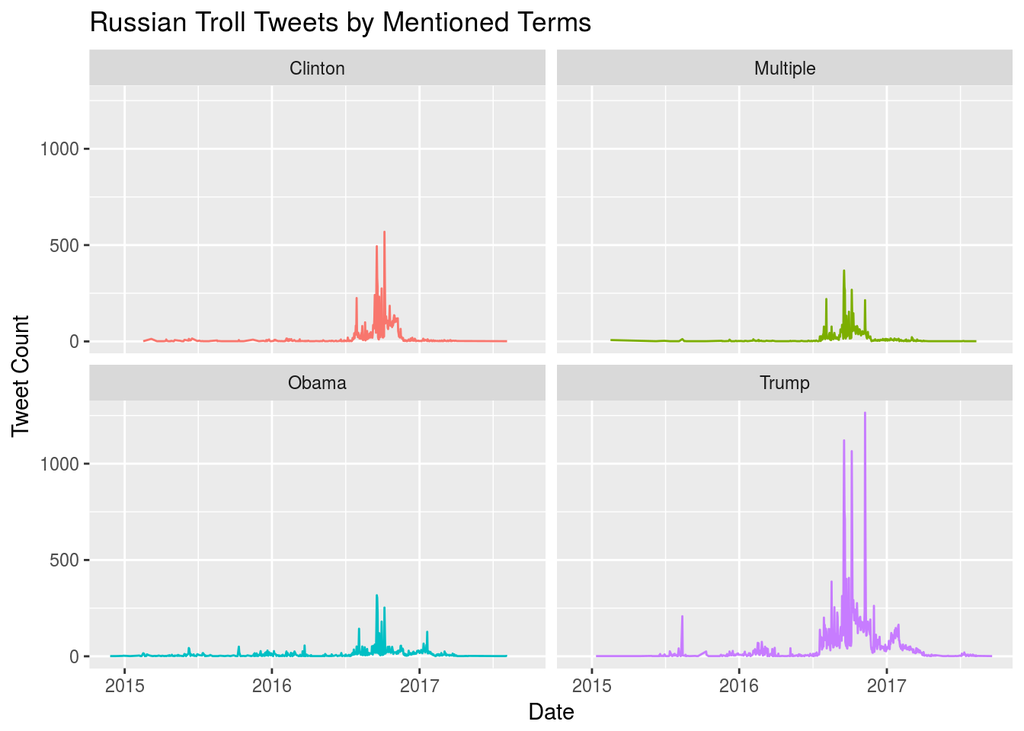

```r
tweets$trump <- grepl("trump", tweets$text, ignore.case = TRUE)
tweets$obama <- grepl("obama", tweets$text, ignore.case = TRUE)
tweets$clinton <- grepl("clinton", tweets$text, ignore.case = TRUE)

tweets %>%
  mutate(term =
    case_when(
      trump + clinton + obama > 1 ~ "Multiple",
      trump == TRUE ~ "Trump",
      clinton == TRUE ~ "Clinton",
      obama == TRUE ~ "Obama"
    )) %>%
  filter(!is.na(term)) %>%
  count(Date = as.Date(created_str), term) %>%
  ggplot(aes(x = Date, y = n, color = term)) +
  geom_line() +
  facet_wrap(~term, ncol = 2) +
  labs(title = "Russian Troll Tweets by Mentioned Terms",
       y = "Tweet Count") +
  theme(legend.position = "none")
```

### Text analysis

To analyze the text, I’m using [`quanteda`](http://docs.quanteda.io/), which is my go-to text analysis package (anywhere). However, another great package that’s easier for beginners is [`tidytext`](https://www.tidytextmining.com/). I simply choose `quanteda` because of its speed and versalility, but `tidytext` has a lot to offer as well. I will however use `tidytext` near the end to analyze my topic model results.

Let’s load `quanteda` and create a corpus as well as keeping the users’ screen_name (handle) on as a corpus feature.

```r
library(quanteda)

corpus <- corpus(tweets$text)
docvars(corpus, "screen_name") <- tweets$user_key
```

Next, we’ll do basic pre-processing to create the dfm (document-feature matrix), that is the core datastructure to keep our document-term matrix and corpus feature in a very efficient sparse matrix.

I trimmed terms that are not in the dataset at least 10 times or in at least 5 tweets (somewhat arbitrary but important to remove very rare/sparse terms).

```r
stopWords <- c("t.co","http","https","amp","t","t.c","c","rt")

dfm <- dfm(corpus,
           remove = c(stopwords("english"), stopWords),
           ngrams= 1L,
           stem = F,
           remove_numbers = TRUE,
           remove_punct = TRUE,
           remove_symbols = TRUE) %>%
  dfm_trim(min_count = 10, min_docfreq = 5)
```

Let’s look at the top words used.

```r
topfeatures(dfm, n = 50)
```

```
##            trump          clinton          hillary            obama
##            24582            10778             9957             7729
##           people             just             like              new
##             6629             6309             5522             5314
##              get           donald              can               us
##             4987             4963             4907             4795
##              now              one @realdonaldtrump              via
##             4766             4703             4582             4369
##            #tcot        #politics        president          america
##             3938             3663             3533             3403
##            black             time             know             make
##             3346             3264             3232             3190
##          trump's              day             says             vote
##             3184             3141             3104             3090
##             want            never            #maga           #pjnet
##             3051             2915             2852             2844
##         election             love            think               go
##             2798             2767             2725             2719
##            white            right             good            media
##             2688             2687             2662             2619
##        @midnight             news              see            video
##             2599             2581             2558             2541
##             need         campaign              say             back
##             2537             2526             2464             2368
##              man  @hillaryclinton
##             2364             2264
```

It’s clear that the top terms used are related to “trump”, “hillary”, “clinton”, and “obama.” This provides direct evidence that these trolls were discussing politically related topics.

### Hashtags

We can then use helpful functions to build a hashtag co-occurrence network.

For this, we’ll run with the top 40 hashtags and create a network in which the nodes are hashatags and the edges are when the hashtags co-occurred in at least 10% of tweets.

```r
tag_dfm <- dfm_select(dfm, ('#*'))

# number of hashtags to show
top <- 40

topfeatures(tag_dfm, top) %>%
  head(n = top)
```

```
##                              #tcot                          #politics
##                               3938                               3663
##                              #maga                             #pjnet
##                               2852                               2844
##                             #trump                              #news
##                               2232                               2126
##                              #ccot                 #merkelmussbleiben
##                               1609                               1133
##                     #wakeupamerica                      #neverhillary
##                               1129                               1122
##                 #trumpforpresident                                #2a
##                               1102                                989
##                        #islamkills                  #blacklivesmatter
##                                930                                870
##                        #trumptrain              #rejecteddebatetopics
##                                784                                723
##                           #hillary             #makeamericagreatagain
##                                676                                671
##               #thingsyoucantignore           #todolistbeforechristmas
##                                670                                629
##       #survivalguidetothanksgiving                                #p2
##                                628                                620
##                #christmasaftermath #alternativeacronyminterpretations
##                                614                                607
##                             #obama                    #hillaryclinton
##                                601                                597
##        #betteralternativetodebates               #reallifemagicspells
##                                597                                596
##                          #teaparty                      #2016in4words
##                                592                                586
##                    #crookedhillary           #giftideasforpoliticians
##                                565                                558
##      #thingsmoretrustedthanhillary                               #gop
##                                541                                538
##            #ruinadinnerinonephrase          #makemehateyouinonephrase
##                                535                                531
##               #idrunforpresidentif                 #ihavearighttoknow
##                                527                                525
##                        #nowplaying                   #secondhandgifts
##                                522                                512
```

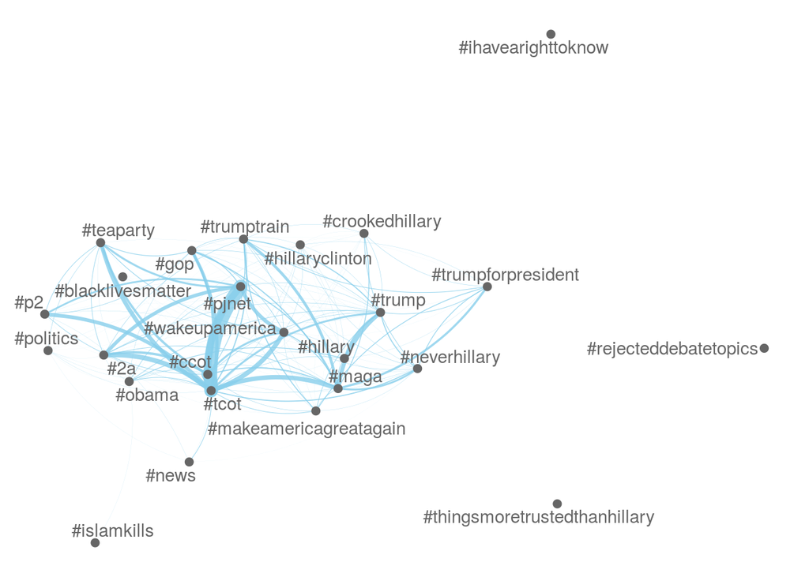

```r
# create co-occurrence matrix and network
fcm(tag_dfm) %>%
  fcm_select(names(topfeatures(tag_dfm, top))) %>%
  textplot_network(min_freq = 0.1, edge_alpha = 0.8, edge_size = 4)
```

### Handles

Similarly, we can do the same thing but for handles (screen_name) mentions.

```r
sn_dfm <- dfm_select(dfm, ('@*'))

# number of hashtags to show
top <- 25

topfeatures(sn_dfm, top) %>%
  head(n = top)
```

```
## @realdonaldtrump        @midnight  @hillaryclinton         @blicqer
##             4582             2599             2264             2238
##  @conservatexian           @potus         @foxnews         @youtube
##             1105              947              760              588
##    @prisonplanet             @cnn         @nine_oh         @ten_gop
##              554              539              538              481
##     @giselleevns    @zaibatsunews  @gerfingerpoken       @wikileaks
##              480              451              450              450
##    @bizpacreview         @thehill     @mitchellvii       @zerohedge
##              415              413              412              409
##     @lindasuhler   @beforeitsnews     @chrixmorgan   @breitbartnews
##              407              402              394              391
##      @talibkweli
##              387
```

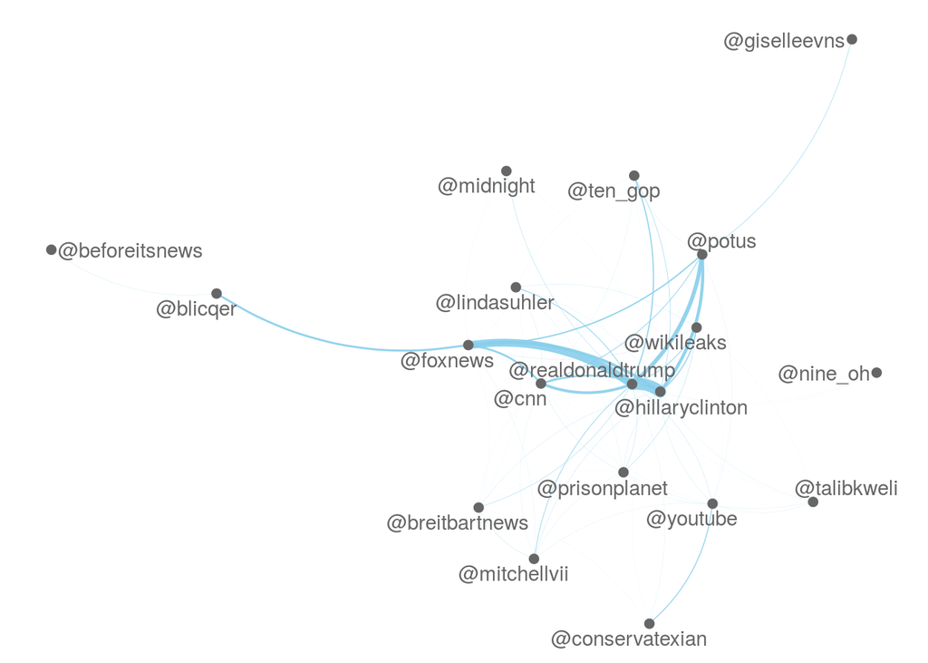

```r
# create co-occurrence matrix and network
fcm(sn_dfm) %>%
  fcm_select(names(topfeatures(sn_dfm, top))) %>%
  textplot_network(min_freq = 0.2, edge_alpha = 0.9, edge_size = 3)
```

### Retweet Network

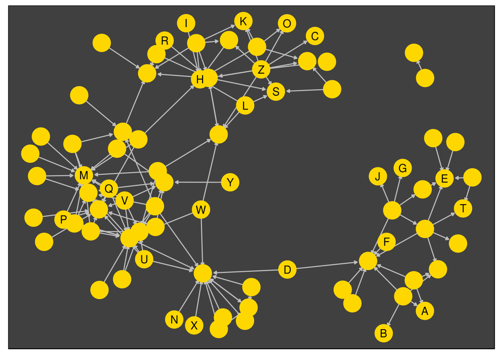

```r
rts <- tweets[grep("RT @", tweets$text),]

names <- unique(rts$user_key)

edges <- tibble(node1 = rts$user_key,
                node2 = gsub('.*RT @([a-zA-Z0-9_]+):? ?.*', rts$text, repl="\\1")) %>%
  filter(node1 %in% names & node2 %in% names) %>%
  group_by(node1, node2) %>%
  summarise(weights = n())

library(igraph)

g <- graph_from_data_frame(d=edges, directed=TRUE)

library(ggraph); library(ggnetwork); library(network)

ggplot(ggnetwork(g, weights = "Frequency"), aes(x = x, y = y, xend = xend, yend = yend)) +
  geom_edges(arrow = arrow(length = unit(3, "pt"), type = "closed"), color = "grey75") +
  geom_nodes(color = "gold", size = 8) +
  geom_nodetext(aes(label = LETTERS[ vertex.names ])) +
  theme_minimal() +
  theme(axis.text = element_blank(),
        axis.title = element_blank(),
        panel.background = element_rect(fill = "grey25"),
        panel.grid = element_blank())
```

### Topic Modeling

For this part, I’ll run Correlated Topic Model using the `stm` package.

First, I’ll need to convert my dfm to the stm data-structure.

```r
library(stm)

# use quanteda converter to convert our Dfm
stmdfm <- convert(dfm, to = "stm")

out <- prepDocuments(stmdfm$documents,
                     stmdfm$vocab,
                     stmdfm$meta,
                     lower.thresh = 10)
```

```
## Removing 1305 of 17177 terms (12867 of 1445758 tokens) due to frequency
## Removing 134 Documents with No Words
## Your corpus now has 200655 documents, 15872 terms and 1432891 tokens.
```

```r
# k = 10 topic for simplicity
k <- 10

ctmFit <- stm(out$documents, out$vocab, K = k,
              max.em.its = 150, data = out$meta, init.type = "Spectral", seed = 300)
```

[output not shown]

[output cut: 197 more lines]

```
## Completing Iteration 40 (approx. per word bound = -8.386, relative change = 1.050e-05)
## Topic 1: want, news, campaign, look, americans
##  Topic 2: us, trump's, vote, says, media
##  Topic 3: clinton, hillary, america, know, good
##  Topic 4: trump, just, @realdonaldtrump, via, make
##  Topic 5: stop, got, bill, die, woman
##  Topic 6: people, like, one, black, white
##  Topic 7: #politics, day, election, #trump, said
##  Topic 8: donald, now, think, right, video
##  Topic 9: obama, #tcot, president, time, #pjnet
##  Topic 10: new, get, can, go, world
## ....................................................................................................
## Completed E-Step (31 seconds).
## Completed M-Step.
## Model Converged
```

Next, let’s use `tidytext` to analyze our results.

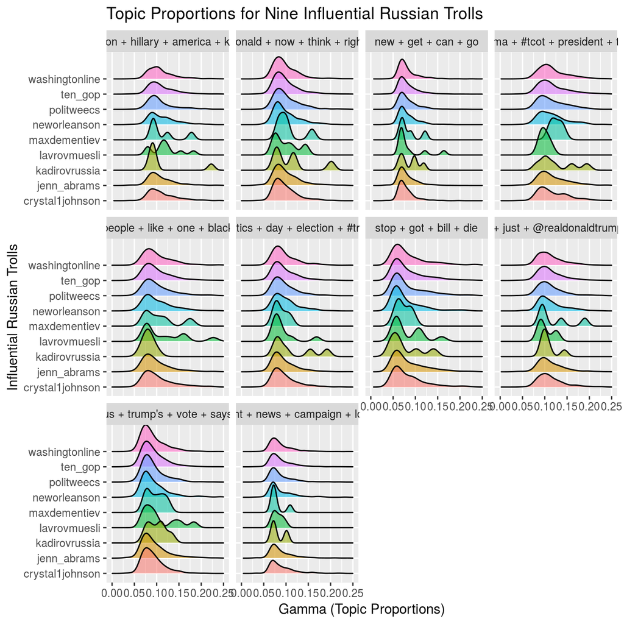

```r
# make sure its version 0.1.6 or higher of tidytext
library(tidytext); library(ggridges)

# tidy the document-topic combinations, with optional document names
td_gamma <- tidy(ctmFit, matrix = "gamma",
                 document_names = stmdfm$meta$screen_name)

userList <- c("jenn_abrams","ten_gop","crystal1johnson",
              "maxdementiev","kadirovrussia","lavrovmuesli",
              "politweecs","washingtonline","neworleanson")

labels <- sageLabels(ctmFit, n = 4)
topicsNames <- sapply(1:10, function(x) paste0(labels$marginal$prob[x,], collapse = " + "))
topics <- tibble(topicsNames,
                 topicNum = 1:10)

td_gamma %>%
  filter(document %in% userList) %>%
  inner_join(topics, by = c("topic" = "topicNum")) %>%
  group_by(document, topic) %>%
  ungroup() %>%
  ggplot(aes(x = gamma, y = document)) +
  geom_density_ridges(aes(fill = document, alpha = 0.1)) +
  facet_wrap(~topicsNames, ncol = 4) +
  labs(title = "Topic Proportions for Nine Influential Russian Trolls",
       x = "Gamma (Topic Proportions)",
       y = "Influential Russian Trolls") +
  xlim(0,0.25) +
  theme(legend.position = "none")
```

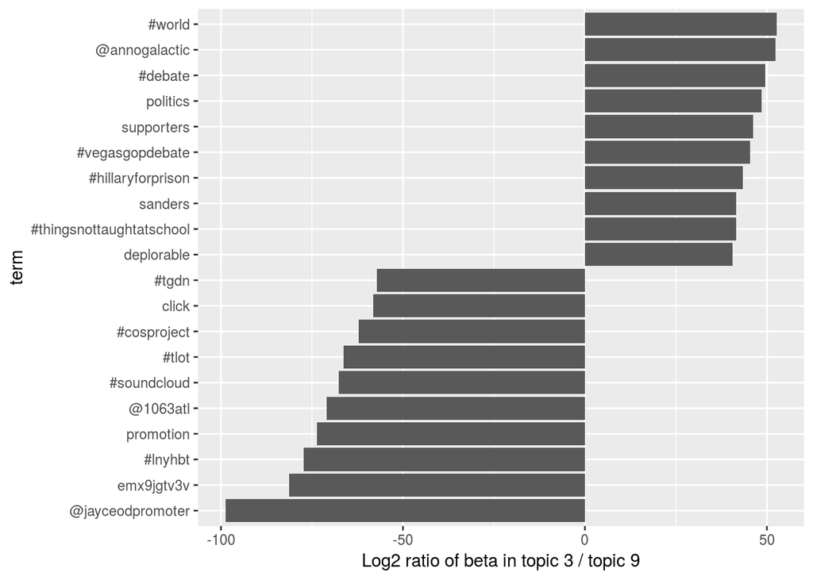

```r
# tidy the word-topic combinations
beta_spread <- tidy(ctmFit) %>%
  mutate(topic = paste0("topic", topic)) %>%
  spread(topic, beta) %>%
  filter(topic3> .001 | topic9 > .001) %>%
  mutate(log_ratio = log2(topic3 / topic9))

beta_spread %>%
  group_by(direction = log_ratio > 0) %>%
  top_n(10, abs(log_ratio)) %>%
  ungroup() %>%
  mutate(term = reorder(term, log_ratio)) %>%
  ggplot(aes(term, log_ratio)) +
  geom_col() +
  labs(y = "Log2 ratio of beta in topic 3 / topic 9") +
  coord_flip()
```

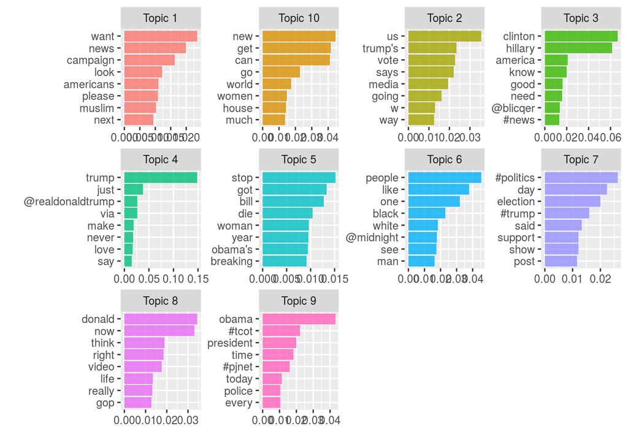

```r
td_beta <- tidy(ctmFit, matrix = "beta")

# helper functions (from David Robinson's R Package)
scale_x_reordered <- function(..., sep = "___") {
  reg <- paste0(sep, ".+$")
  ggplot2::scale_x_discrete(labels = function(x) gsub(reg, "", x), ...)
}

reorder_within <- function(x, by, within, fun = mean, sep = "___", ...) {
  new_x <- paste(x, within, sep = sep)
  stats::reorder(new_x, by, FUN = fun)
}

# Examine the topics
td_beta %>%
  group_by(topic) %>%
  top_n(8, beta) %>%
  ungroup() %>%
  mutate(topic = paste0("Topic ", topic),
           term = reorder_within(term, beta, topic)) %>%
  ggplot(aes(term, beta, fill = topic)) +
  geom_col(alpha = 0.8, show.legend = FALSE) +
  facet_wrap(~ topic, ncol = 4, scales = "free") +
  scale_x_reordered() +
  coord_flip() +
  labs(x = "",
       y = "")
```

### Next Steps

There’s a lot more analysis that could be done on this dataset.

Some ideas include:

- **prevalance covariates**: Consider using structural topic modeling to introduce covariates (e.g., time or feature extraction for specialized features). These features can be used to measure their effect of time on what topics were discussed.
- Explore the links the users posted. This is key to understand what information they’re disseminating to different sites. For example, see [Starbird](http://faculty.washington.edu/kstarbi/Alt_Narratives_ICWSM17-CameraReady.pdf) (2017).
- Dig into the retweet network. I created a retweet network yet what properties can be found?

#### Save info

```r
save.image("RussianTrolls.RData")
```